This analysis starts right after the creation of the coverage centroids plot on slide 16 of Chart Dump.

```r
require(sp)
require(ggmap)
require(sf)
require(rgeos)
require(tidyr)
require(dplyr)
require(rgdal)
require(stringr)
require(auk)
require(lubridate)
require(reshape2)
require(lme4)
require(DHARMa)
library(gridExtra)
```

Set the crs used in all analysis as a memorable variable. Set a boolean varialbe for if the markdown should generate hundreds of species and family specific maps.

```r
crs.m <- 32619
generate.maps <- FALSE
```

Read in data

```r
bba1m <- readRDS("rds-files\\bba1m.rds")

block.covs <- readRDS("rds-files\\block.covs.rds")
bba2m <- readRDS("rds-files\\bba2m.rds")

bba1m.dist <- readRDS("rds-files\\bba1m_distribution.rds")
bba2m.dist <- readRDS("rds-files\\bba2m_distribution.rds")
common.a1 <- readRDS("rds-files\\common_species1.rds")
common.a2 <- readRDS("rds-files\\common_species2.rds")
block.covs <- readRDS("rds-files\\land_coverage_by_block.rds")


shape <- read_sf(dsn = "..\\state_outline", layer = "State_Outline_v5")
```

Initialize map of Maine with A2 quads

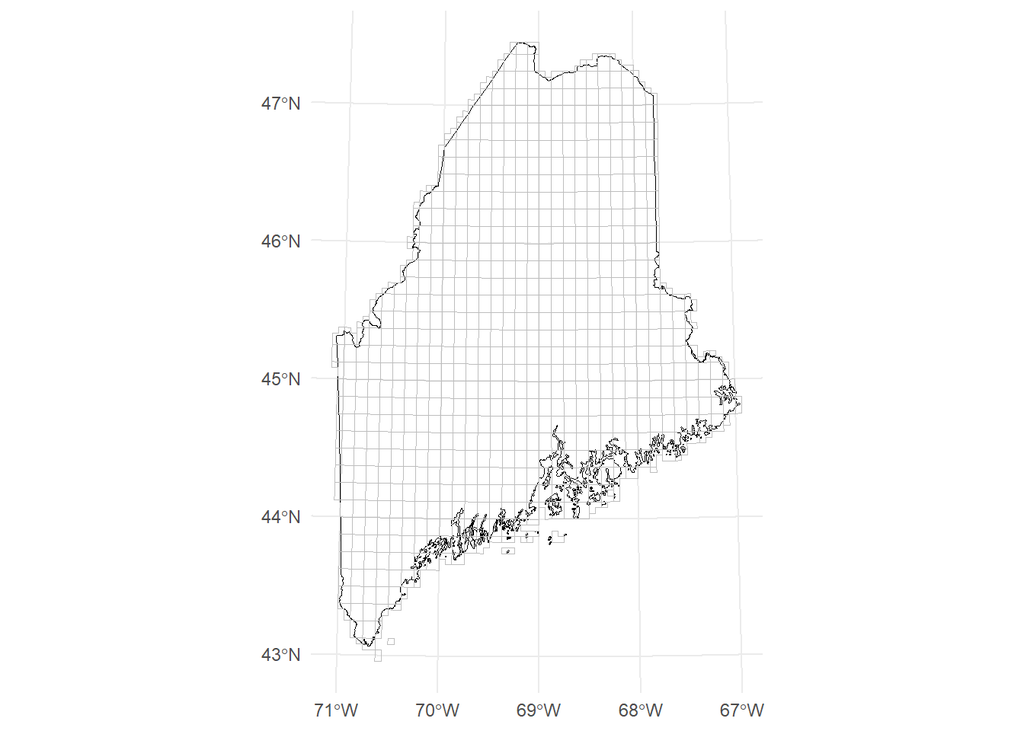

```r
shape <- st_transform(shape, crs = st_crs(bba2m))
maine <- shape %>%
  filter(STATE == 'Maine')

maine_shape <- ggplot(maine) +
  geom_sf(fill = NA, color = "black") +
  theme_minimal()

maine_quads <- ggplot(maine) +
  geom_sf(fill = NA, color = "black") +
  geom_sf(data = bba2m, aes(geometry = geometry), color = "grey", fill = NA) +
  theme_minimal()


maine_quads
```

Read in ME coast shapefile https://catalog.data.gov/dataset/tiger-line-shapefile-2019-nation-u-s-coastline-national-shapefile

Also counties from https://www.census.gov/geographies/mapping-files/time-series/geo/cartographic-boundary.html

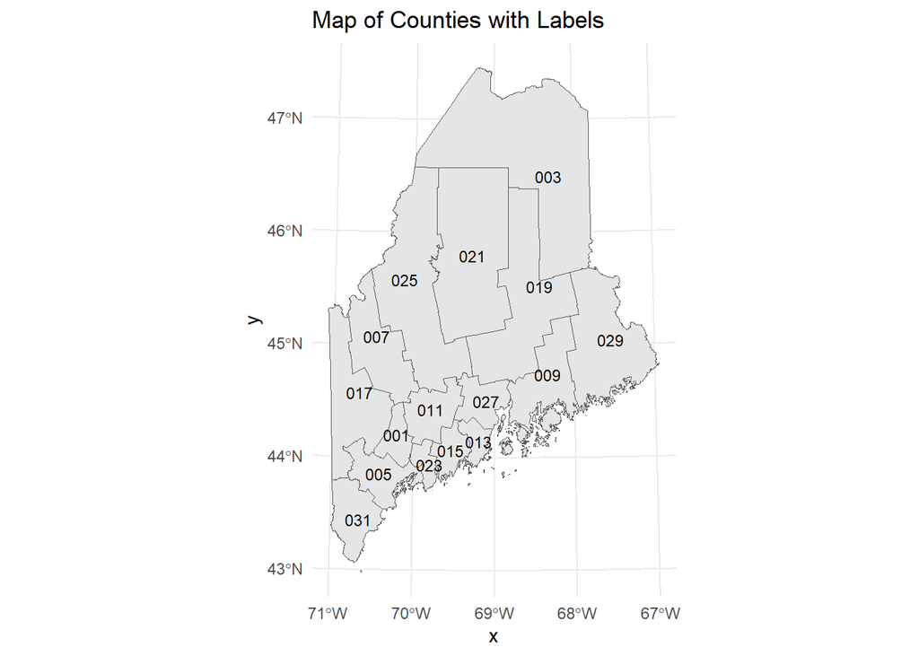

```r
# make a simple map of Maine counties
me.county <- read_sf("counties-shape")
me.county <- me.county %>%
  group_by(COUNTYFP) %>%
  summarize(geometry = st_union(geometry))
me.county <- st_transform(me.county, crs.m)
# plot(me.county)
ggplot(data = me.county) +
  geom_sf() + geom_sf_text(aes(label = COUNTYFP), size = 3, color = 'black') +
  labs(title = 'Map of Counties with Labels') + theme_minimal()
```

Visually compare coverage in A1 to county lines

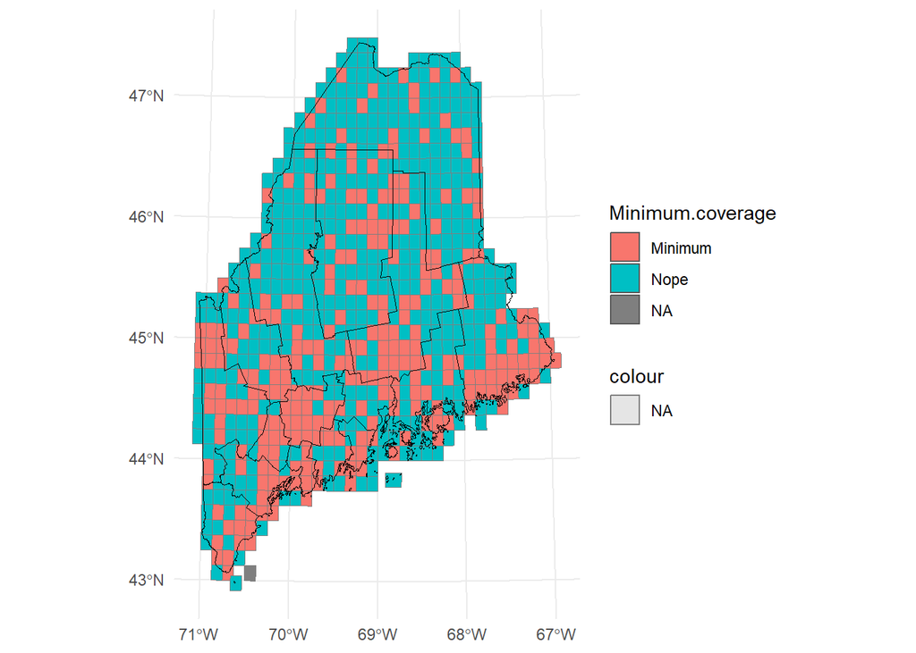

```r
ggplot() +
  geom_sf(data = bba1m, aes(geometry = geometry,
                            color = NA, fill = Minimum.coverage)) +
  geom_sf(data = me.county, aes(geometry = geometry), color = "black",
                                fill = NA, alpha = 0.0, show.legend = FALSE) +
  theme_minimal()
```

Initialize by_county a function that performs a spatial join between a given atlas and Maine’s counties.

```r
by_county <- function(atlas, cut) {
  atlas.county <- sf::st_drop_geometry(atlas)
  if(cut) {
    # cut data.frame down to a few columns: coverage and geographic variables
    atlas.county <- subset(atlas.county,
                           select=c('coverage', 'centroid', 'avg.ele', 'd.to.coast'))
  }


  atlas.county <- atlas.county %>%
    # break the spatial point into numeric values
    mutate(quad.lon = st_coordinates(centroid)[, 1]) %>%
    mutate(quad.lat = st_coordinates(centroid)[, 2])
  atlas.county <-  st_as_sf(atlas.county)
  # something is going wrong witht his join
  atlas.county <- atlas.county %>%
    st_join(me.county)

  # drop the centroid column
  atlas.county$centroid <- NULL
  atlas.county$coverage

  atlas.county <- atlas.county %>%
    filter(!is.na(COUNTYFP))
  return(atlas.county)
}
```

There is an error in spatial join in the chunk above. A2 is picking up more quads in its spatial join than A1, and neither of them are gaining all quads.

```r
a1.c <- by_county(bba1m, TRUE)
a2.c <- by_county(bba2m, TRUE)
a1.quad.tally <- a1.c %>%
  group_by(COUNTYFP) %>%
  tally()
a2.quad.tally <-  a2.c %>%
  group_by(COUNTYFP) %>%
  tally()
quad.tally.dif <- a2.quad.tally$n - a1.quad.tally$n
quad.tally.dif
```

```
##  [1] 0 3 1 1 3 0 0 0 3 0 0 0 3 0 5 1
```

Initialize a county based data frame containing: weighted centroids, weighted elevations, and weighted distance to coast data

```r
# load groupable data
# c stands for county
a1.c <- by_county(bba1m, TRUE)

# normalize the coverage
framed.c <- a1.c %>%
  group_by(COUNTYFP) %>%
  reframe(coverage = (coverage / mean(coverage)), quad.lon = quad.lon,
          quad.lat = quad.lat, avg.ele = avg.ele, d.to.coast = d.to.coast)

a1.c <- framed.c %>%
  group_by(COUNTYFP) %>%
  reframe(avg.lon = mean(quad.lon * coverage),
          avg.lat = mean(quad.lat * coverage),
          w.ele.a1 = mean(avg.ele * coverage),
          w.coast.a1 = mean(d.to.coast * coverage)
          )

a1.c <- as.data.frame(a1.c)

a1.c <- st_as_sf(a1.c, coords = c(2:3), sf_column_name = 'w.centroid',
                     crs = crs.m)

# load in atlas 2 county data
a2.c <- by_county(bba2m, TRUE)

a2.c <- a2.c %>%
  group_by(COUNTYFP) %>%
  reframe(avg.to.coast = mean(d.to.coast),
          # convert average elevation of a quad to average elevation of a county
          avg.ele = mean(avg.ele))



# COUNTYFP is in the same order for both a1 and a2
me.county <- me.county %>%
  # this line defines A2 centroid as unbiased
  mutate(w.centroid.a2 = st_centroid(geometry)) %>%
  mutate(w.centroid.a1 = a1.c$w.centroid) %>%
  mutate(w.coast.a1 = a1.c$w.coast.a1) %>%
  mutate(w.ele.a1 = a1.c$w.ele.a1) %>%
  # changing the names of a2 coast and elevation for clarity
  mutate(w.coast.a2 = a2.c$avg.to.coast) %>%
  mutate(w.ele.a2 = a2.c$avg.ele)

me.county
```

```
## Simple feature collection with 16 features and 5 fields
## Active geometry column: geometry
## Geometry type: GEOMETRY
## Dimension:     XY
## Bounding box:  xmin: 336630.3 ymin: 4759600 xmax: 662092.2 ymax: 5256274
## Projected CRS: WGS 84 / UTM zone 19N
## # A tibble: 16 × 8
##    COUNTYFP                                   geometry      w.centroid.a2
##  * <chr>                                <GEOMETRY [m]>        <POINT [m]>
##  1 001      POLYGON ((396388.3 4875052, 398567.6 4872… (403539.1 4890969)
##  2 003      POLYGON ((522875.7 5231962, 522566.6 5231… (530992.1 5167123)
##  3 005      MULTIPOLYGON (((413044.3 4839896, 413697.… (387573.7 4855769)
##  4 007      POLYGON ((386736.6 5010246, 385528.7 5017… (386233.2 4980968)
##  5 009      MULTIPOLYGON (((532939 4888138, 533110.3 … (550785.3 4945754)
##  6 011      POLYGON ((417687.7 4928828, 417543.5 4928… (438876.7 4917581)
##  7 013      MULTIPOLYGON (((508509.4 4875556, 508700.… (486533.1 4887546)
##  8 015      MULTIPOLYGON (((467563.1 4895353, 467758.… (456464.4 4879370)
##  9 017      POLYGON ((339983.3 4860176, 340027.7 4855… (360409.6 4928681)
## 10 019      POLYGON ((544207.9 5057298, 544271.9 5067… (527320.7 5027151)
## 11 021      POLYGON ((481741.9 4992993, 490166.6 4994… (477886.2 5075694)
## 12 023      MULTIPOLYGON (((438764.8 4839453, 438992.… (431448.4 4867740)
## 13 025      POLYGON ((451117.9 4936347, 451598.6 4936…   (425212 5040000)
## 14 027      MULTIPOLYGON (((478575.1 4912410, 480117.… (488441.9 4927714)
## 15 029      MULTIPOLYGON (((611244.2 4921996, 611411.… (608058.1 4987135)
## 16 031      MULTIPOLYGON (((372580 4793644, 372621.8 … (361359.1 4815304)
## # ℹ 5 more variables: w.centroid.a1 <POINT [m]>, w.coast.a1 [m],
## #   w.ele.a1 <dbl>, w.coast.a2 [m], w.ele.a2 <dbl>
```

Plot the two weighted centroids for each county. The weights for atlas 2 are assumed to be evenly distributed

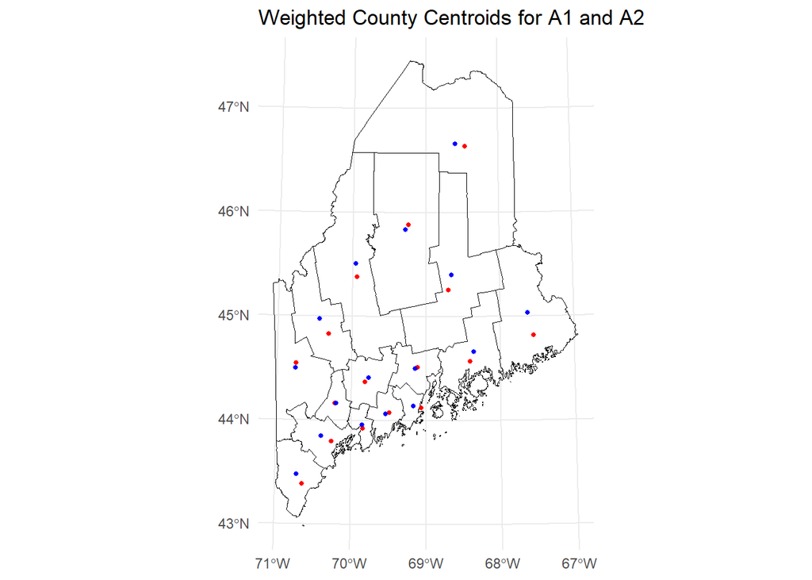

```r
ggplot() +
  geom_sf(data = me.county, aes(geometry = geometry), color = "black", fill = NA,
          alpha = 0.0) +

  geom_sf(data = me.county, aes(geometry = w.centroid.a1), size = 1, shape = 21,
          color = "red", fill = "red") +

  geom_sf(data = me.county, aes(geometry = w.centroid.a2), color = "blue",
          size = 1, shape = 21, fill = "blue") +
  # scale_color_manual(breaks = c("A1", "A2"), values =  c("red", "blue")) +
  ggtitle("Weighted County Centroids for A1 and A2") +
  theme_minimal()
```

Calculate coverage bias for all 4 categories (lat, lon, elevation, distance from coast) Unique set of values for each county

```r
# a2 - a1 for all calculations
me.county <- me.county %>%
  mutate(da.lon = st_coordinates(w.centroid.a2)[, 1] -
           st_coordinates(w.centroid.a1)[, 1]) %>%
  mutate(da.lat = st_coordinates(w.centroid.a2)[, 2] -
           st_coordinates(w.centroid.a1)[, 2]) %>%
  mutate(da.ele = w.ele.a2 - w.ele.a1) %>%
  mutate(da.coast = w.coast.a2 - w.coast.a1)
me.county
```

```
## Simple feature collection with 16 features and 9 fields
## Active geometry column: geometry
## Geometry type: GEOMETRY
## Dimension:     XY
## Bounding box:  xmin: 336630.3 ymin: 4759600 xmax: 662092.2 ymax: 5256274
## Projected CRS: WGS 84 / UTM zone 19N
## # A tibble: 16 × 12
##    COUNTYFP                                   geometry      w.centroid.a2
##  * <chr>                                <GEOMETRY [m]>        <POINT [m]>
##  1 001      POLYGON ((396388.3 4875052, 398567.6 4872… (403539.1 4890969)
##  2 003      POLYGON ((522875.7 5231962, 522566.6 5231… (530992.1 5167123)
##  3 005      MULTIPOLYGON (((413044.3 4839896, 413697.… (387573.7 4855769)
##  4 007      POLYGON ((386736.6 5010246, 385528.7 5017… (386233.2 4980968)
##  5 009      MULTIPOLYGON (((532939 4888138, 533110.3 … (550785.3 4945754)
##  6 011      POLYGON ((417687.7 4928828, 417543.5 4928… (438876.7 4917581)
##  7 013      MULTIPOLYGON (((508509.4 4875556, 508700.… (486533.1 4887546)
##  8 015      MULTIPOLYGON (((467563.1 4895353, 467758.… (456464.4 4879370)
##  9 017      POLYGON ((339983.3 4860176, 340027.7 4855… (360409.6 4928681)
## 10 019      POLYGON ((544207.9 5057298, 544271.9 5067… (527320.7 5027151)
## 11 021      POLYGON ((481741.9 4992993, 490166.6 4994… (477886.2 5075694)
## 12 023      MULTIPOLYGON (((438764.8 4839453, 438992.… (431448.4 4867740)
## 13 025      POLYGON ((451117.9 4936347, 451598.6 4936…   (425212 5040000)
## 14 027      MULTIPOLYGON (((478575.1 4912410, 480117.… (488441.9 4927714)
## 15 029      MULTIPOLYGON (((611244.2 4921996, 611411.… (608058.1 4987135)
## 16 031      MULTIPOLYGON (((372580 4793644, 372621.8 … (361359.1 4815304)
## # ℹ 9 more variables: w.centroid.a1 <POINT [m]>, w.coast.a1 [m],
## #   w.ele.a1 <dbl>, w.coast.a2 [m], w.ele.a2 <dbl>, da.lon <dbl>, da.lat <dbl>,
## #   da.ele <dbl>, da.coast [m]
```

Initialize a species list for each county and species_by_county: a function that takes in an atlas and its corresponding species list and returns a data.frame with the number of times each species occurs in each county and the number of quads in that county.

```r
# create atlas 1 species list to iterate through
start_col <- which(names(bba1m) == "American Black Duck")
end_col <- which(names(bba1m) == "Yellow-throated Vireo")
species.a1 <- colnames(bba1m)[start_col:end_col]
# create atlas 2 species list to iterate through
start_col <- which(names(bba2m) == "Acadian Flycatcher")
end_col <- which(names(bba2m) == "Yellow Warbler" )
species.a2 <- colnames(bba2m)[start_col:end_col]


species_by_county <- function(atlas, species) {
  sums.atlas <- subset(me.county, select=c('COUNTYFP'))
  # find the number of quads a species is in for each county
  for(s in species) {
    atlas <- atlas %>%
      mutate(across(all_of(s), ~ ifelse(is.na(.), 0, .))) %>%
      mutate(across(all_of(s), ~ ifelse(. > 0, 1, 0)))
    single.sums <- atlas %>%
        group_by(COUNTYFP) %>%
        reframe(!!sym(s) := sum(!!sym(s)))
    sums.atlas <- left_join(sums.atlas, single.sums, by = "COUNTYFP")

  }
  # create a data.frame with a column n that contains the number of quads for each county
  quads.c <- atlas %>%
      group_by(COUNTYFP) %>%
      tally()
  quads.c <- sf::st_drop_geometry(quads.c)
  sums.atlas <- left_join(sums.atlas, quads.c, by = 'COUNTYFP')
  return(sums.atlas)

}
```

Produce sums.a1 and sums.a2 data.frames using species_by_county(). These data.frames contain the number of quads a species occurs in within each county and the total number of quads each county contains.

```r
# load in fresh bbam datasets with counties
# c stands for county
a1.c <- by_county(bba1m, FALSE)
a2.c <- by_county(bba2m, FALSE)


sums.a1 <- species_by_county(a1.c, species.a1)
sums.a2 <- species_by_county(a2.c, species.a2)
sums.a2
```

```
## Simple feature collection with 16 features and 245 fields
## Geometry type: GEOMETRY
## Dimension:     XY
## Bounding box:  xmin: 336630.3 ymin: 4759600 xmax: 662092.2 ymax: 5256274
## Projected CRS: WGS 84 / UTM zone 19N
## # A tibble: 16 × 246
##    COUNTYFP                     geometry `Acadian Flycatcher` `Alder Flycatcher`
##    <chr>                  <GEOMETRY [m]>                <dbl>              <dbl>
##  1 001      POLYGON ((396388.3 4875052,…                    0                  9
##  2 003      POLYGON ((522875.7 5231962,…                    0                131
##  3 005      MULTIPOLYGON (((413044.3 48…                    1                 18
##  4 007      POLYGON ((386736.6 5010246,…                    0                 28
##  5 009      MULTIPOLYGON (((532939 4888…                    0                 33
##  6 011      POLYGON ((417687.7 4928828,…                    0                 19
##  7 013      MULTIPOLYGON (((508509.4 48…                    0                  7
##  8 015      MULTIPOLYGON (((467563.1 48…                    0                  9
##  9 017      POLYGON ((339983.3 4860176,…                    0                 40
## 10 019      POLYGON ((544207.9 5057298,…                    0                 72
## 11 021      POLYGON ((481741.9 4992993,…                    0                 78
## 12 023      MULTIPOLYGON (((438764.8 48…                    0                  5
## 13 025      POLYGON ((451117.9 4936347,…                    0                 71
## 14 027      MULTIPOLYGON (((478575.1 49…                    0                 14
## 15 029      MULTIPOLYGON (((611244.2 49…                    0                 53
## 16 031      MULTIPOLYGON (((372580 4793…                    0                 20
## # ℹ 242 more variables: `American Bittern` <dbl>, `American Black Duck` <dbl>,
## #   `American Coot` <dbl>, `American Crow` <dbl>, `American Goldfinch` <dbl>,
## #   `American Goshawk` <dbl>, `American Kestrel` <dbl>,
## #   `American Oystercatcher` <dbl>, `American Pipit` <dbl>,
## #   `American Redstart` <dbl>, `American Robin` <dbl>,
## #   `American Three-toed Woodpecker` <dbl>, `American Wigeon` <dbl>,
## #   `American Woodcock` <dbl>, `Arctic Tern` <dbl>, `Atlantic Puffin` <dbl>, …
```

Create 2 data.frames representing only species that occur in at least 40 quads

```r
# initialize frequent lists containing any species w 40 or more quads
# b stands for biased
b.freq.a1 <- common.a1 %>%
  filter(num.blocks > 39)
b.freq.a2 <- common.a2 %>%
  filter(num.blocks > 39)
# cuts out 58 species leaving us with only 145 species

# make sure they contain only species in both species lists
common.species <- intersect(b.freq.a1$species, b.freq.a2$species)
b.freq.a1 <- b.freq.a1 %>%
  filter(species %in% common.species)
b.freq.a2 <- b.freq.a2 %>%
  filter(species %in% common.species)
common.cols <- intersect(names(b.freq.a1), names(b.freq.a2))
b.freq.a1 <- b.freq.a1[common.cols]
b.freq.a2 <- b.freq.a2[common.cols]
# ensure the same order of species
b.freq.a1 <- b.freq.a1 %>% arrange(species)
b.freq.a2 <- b.freq.a2 %>% arrange(species)
# this last line ensures common.species is in the proper order
# which will become important when applying bias adjustments
common.species <- b.freq.a1$species

b.freq.a2 <- b.freq.a2 %>%
  mutate(lat.change = lat - b.freq.a1$lat) %>%
  mutate(lon.change = lon - b.freq.a1$lon) %>%
  mutate(ele.change = avg.ele - b.freq.a1$avg.ele) %>%
  mutate(coast.change = d.to.coast - b.freq.a1$d.to.coast)
```

```r
bias.weights <- data.frame(
  COUNTYFP = sums.a1$COUNTYFP
)
# initialize biases as values in the range 0 - 1
for (i in common.species) {
  bias.weights[[i]]  <- (sums.a1[[i]] + sums.a2[[i]]) / (sums.a2$n * 2)
}

# find the total bias of each county
bias.weights <- bias.weights %>%
  rowwise() %>%
  mutate(total_county_bias = sum(c_across(-1)))

# scale each individual weight according to total county bias
for (i in common.species) {
  bias.weights[[i]] <- bias.weights[[i]] * bias.weights$total_county_bias
}
# scale biases such that the sum of each species bias = 1
for (i in common.species) {
  total <- sum(bias.weights[[i]])
  bias.weights[[i]] <- sapply(bias.weights[[i]], function(x) {x / total})
}
```

Save the two sums datasets and the bias weights datasets to CSVs.

```r
write.csv(bias.weights, "bias_weights.csv", row.names=FALSE, quote=FALSE)
sums.a1.nogeo <- sf::st_drop_geometry(sums.a1)
sums.a2.nogeo <- sf::st_drop_geometry(sums.a2)
write.csv(sums.a1.nogeo, "a1_present_in_n_quads.csv", row.names=FALSE, quote=FALSE)
write.csv(sums.a2.nogeo, "a2_present_in_n_quads.csv", row.names=FALSE, quote=FALSE)
```

Apply bias adjustments to freq.a1

```r
bias.lon <- bias.lat <- bias.ele <- bias.coast <- vector()
for (i in common.species) {
  # longitude (m)
  lon <- mean(me.county$da.lon * bias.weights[[i]])
  bias.lon <- c(bias.lon, lon)
  # latitude (m)
  lat <- mean(me.county$da.lat * bias.weights[[i]])
  bias.lat <- c(bias.lat, lat)
  # elevation (m)
  ele <- mean(me.county$da.ele * bias.weights[[i]])
  bias.ele <- c(bias.ele, ele)
  # distance to coast (m)
  coast <- mean(me.county$da.coast * bias.weights[[i]])
  bias.coast <- c(bias.coast, coast)
}
freq.a1 <- b.freq.a1 %>%
  mutate(lon = lon + bias.lon) %>%
  mutate(lat = lat + bias.lat) %>%
  # changing the name of avg elevation to elevation for consistency
  # (these values are all averages)
  mutate(ele = avg.ele + bias.ele) %>%
  mutate(d.to.coast = d.to.coast + bias.coast)


freq.a1$d.to.coast
```

```
##   [1]  71816.1746  80834.1905  77130.2159  70923.7787  63271.9150  57932.0533
##   [7]  77593.6343  81860.0172  71649.7105  77646.0793  54608.9122  54011.7513
##  [13]  75418.1776  56646.7694 127733.7584  75448.0418   1148.1681  66124.9418
##  [19] 129396.2809  34850.9370  75923.8704  88856.6864  75449.8686  95028.1002
##  [25] 117028.4565  79504.4495  85189.2747  56159.2232 122198.0864  71290.3247
##  [31]  70991.8913  42879.8585  56285.8828  59772.1324 139186.5410  83418.6012
##  [37] 128129.9602  74841.4332  71184.3385  67615.6923  80184.2436  53508.1168
##  [43]    651.4697 146275.9047  78463.2147 100298.0449 140828.3014  63704.5568
##  [49]  94619.6902  56014.7827  78988.8981 105495.8158   4044.3143  66769.4544
##  [55]  49591.3828  69368.2158  34980.6163  45948.4445  39663.1554  25590.5411
##  [61]  70322.7687  54894.5005 122308.1366  44002.4926  93116.0659  59568.5433
##  [67]   1454.2095  68322.4755  49715.0242  51748.2664  29425.8346  79648.4998
##  [73]  73252.1183  81520.6914  63580.3033  85193.6647  21915.8491  42450.3452
##  [79]  57500.1766  44878.1635  60511.2513  85334.7424 125825.0678  90664.3181
##  [85]  47896.7159  32933.5539  39047.0012 148762.8299  82619.4703  32381.5465
##  [91]  76186.4336  74011.5995  47704.1715  87925.4909  39425.8228  65368.9891
##  [97]  87725.9360  89288.0971  83498.2666  80578.9812  84474.4969  72300.8529
## [103]  88885.2362 101638.6617  49675.9476  81985.9979  81567.7092  77677.8524
## [109]  48777.4175 100221.0942  77907.8565 106171.9586  36472.6885  82944.1214
## [115] 111534.1030  71236.0065  83845.9132 156277.9261  60449.4292  73055.0803
## [121]  68062.8371  73478.8563  81425.6101 115330.1984 119906.2048  70085.2035
## [127] 128143.3324  75344.6937  80176.5908  39049.1210  25282.7870  52134.3774
## [133]  49510.3124  85529.3987  59509.1930  97535.8010 103842.6899 100274.6579
## [139]  68190.6869  68504.2935  50362.8543 101406.2593  96232.0669  40159.0883
## [145]  80794.4940
```

Create new columns in freq.a2 representing change since atlas 1. A southern, western, or decreasing shift from A1 to A2 will be represented as a negative value.

```r
# no coverage bias in a2
freq.a2 <- b.freq.a2 %>%
  mutate(lat.change = lat - freq.a1$lat) %>%
  mutate(lon.change = lon - freq.a1$lon) %>%
  mutate(ele.change = avg.ele - freq.a1$avg.ele) %>%
  mutate(coast.change = d.to.coast - freq.a1$d.to.coast)
```

THIS NEXT CHUNK CONTAINS ENTIRELY OUTDATE CODE TO COMPARE THE OLD BIAS ADJUSTMENT Calculate outdated coverage bias for all 4 categories (lat, lon, elevation, distance from coast) Then apply those bias adjustments to o.freq.a1 o stands for old biases

```r
w_centroid <- function(atlas) {
  coords <- st_coordinates(atlas$centroid)
  # this weights the a1 coordinates of the subjective 0 1 2 coverage
  # classification system
  weighted_coords <- coords * atlas$coverage
  sum_weighted_coords <- colSums(weighted_coords)
  total_coverage <- sum(atlas$coverage)
  weighted_centroid <- sum_weighted_coords / total_coverage
  weighted_centroid_sf <- st_point(weighted_centroid)
  return(weighted_centroid_sf)
}
# coverage center change plot
# centroid_1 <- w_centroid(bba1m)
# str(centroid_1)
cov.centroids <- c(w_centroid(bba1m), w_centroid(bba2m))
cov.centroids
```

```
## MULTIPOINT ((479303.3 4976293), (481438.3 4996430))
```

```r
coords <- st_coordinates(cov.centroids)

list_of_points <- split(coords, seq(nrow(coords)))

sf_multipoint <- st_sfc(st_multipoint(do.call(rbind, list_of_points)))

sf_multipoint <- st_set_crs(sf_multipoint, 32619)


coords <- st_coordinates(sf_multipoint)
coverage.centroids <- as.data.frame(coords)
coverage.centroids <-
  coverage.centroids[, -((ncol(coverage.centroids) - 1):ncol(coverage.centroids))]

# Rename columns for easier plotting
colnames(coverage.centroids) <- c("lon", "lat")
coverage.centroids$point_id <- factor(c("A1", "A2"))
# Create the plot using ggplot2
plot.coverage.centroids <- maine_quads +
  geom_point(data = coverage.centroids, aes(x = lon, y = lat, color = point_id), size = 1) +
  theme_minimal() +
  labs(title = "Coverage Centroid for A1 and A2") +
  coord_sf(crs = st_crs(32619)) +
  theme(legend.position = "right")
coverage.centroids
```

```
##        lon     lat point_id
## 1 479303.3 4976293       A1
## 2 481438.3 4996430       A2
```

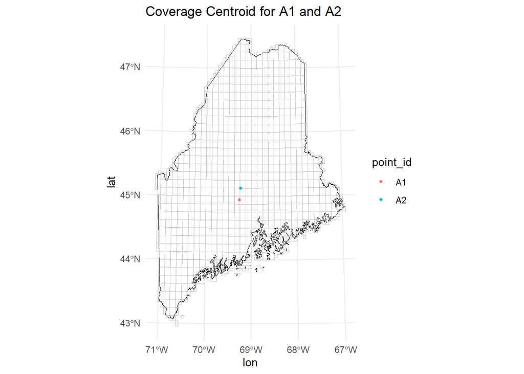

```r
plot.coverage.centroids
```

```r
#########
# Calculate da.lat
# all adjustments except elevation are in meters
# latitude
da.lat <- coverage.centroids$lat[[1]] - coverage.centroids$lat[[2]]
paste0('latitudinal bias: ', da.lat, ' meters')
```

```
## [1] "latitudinal bias: -20136.4734880319 meters"
```

```r
#longitude
da.lon <- coverage.centroids$lon[[1]] - coverage.centroids$lon[[2]]
paste0('longitudinal bias: ', da.lon, ' meters')
```

```
## [1] "longitudinal bias: -2134.96657647128 meters"
```

```r
# change in elevation is measured in m
bba1m$w.ele.cov <- bba1m$avg.ele * bba1m$coverage
bba2m$w.ele.cov <- bba2m$avg.ele * bba2m$coverage
da.ele <- mean(bba1m$w.ele.cov - bba2m$w.ele.cov)
paste0('elevation bias: ', da.ele, ' meters')
```

```
## [1] "elevation bias: -0.0276910244961813 meters"
```

```r
#coast
bba1m$w.coast.cov <- bba1m$distance_to_coast * bba1m$coverage
bba2m$w.coast.cov <- bba2m$distance_to_coast * bba2m$coverage
da.coast <- mean(bba1m$w.coast.cov - bba2m$w.coast.cov)
paste0('coastal distance bias: ', da.coast, ' meters')
```

```
## [1] "coastal distance bias: -22.7256984890408 meters"
```

```r
o.freq.a1 <- b.freq.a1 %>%
  mutate(lat = lat + da.lat) %>%
  mutate(lon = lon + da.lon) %>%
  mutate(avg.ele = avg.ele + da.ele) %>%
  mutate(d.to.coast = d.to.coast + da.coast)
o.freq.a1
```

```
## Simple feature collection with 145 features and 31 fields
## Geometry type: POINT
## Dimension:     XY
## Bounding box:  xmin: 420944.5 ymin: 4868518 xmax: 538699.4 ymax: 5075298
## Projected CRS: WGS 84 / UTM zone 19N
## First 10 features:
##                species   s.lat   n.lat num.blocks  avg.ele   med.ele    w.lon
## 1     Alder Flycatcher 4792801 5226184        317 177.8161 130.00561 342766.8
## 2     American Bittern 4817404 5220640        184 187.4340 144.01603 349974.0
## 3  American Black Duck 4788921 5223480        315 179.4450 141.77986 344047.0
## 4        American Crow 4787267 5230377        431 183.5268 138.22081 341283.5
## 5   American Goldfinch 4788600 5223404        393 172.3083 125.49129 342532.3
## 6     American Kestrel 4794085 5216549        287 154.8559 113.92425 343686.1
## 7    American Redstart 4783507 5228979        462 198.5821 152.84692 340500.2
## 8       American Robin 4787267 5231744        502 200.4167 160.58498 340435.2
```

[output cut: 46 more lines]

```r
o.freq.a2 <- b.freq.a2 %>%
  mutate(lat.change = lat - o.freq.a1$lat) %>%
  mutate(lon.change = lon - o.freq.a1$lon) %>%
  mutate(ele.change = avg.ele - o.freq.a1$avg.ele) %>%
  mutate(coast.change = d.to.coast - o.freq.a1$d.to.coast)
```

Create a data.frame to compare unadjusted, old bias adjustments, and new bias adjustments

```r
b.bias.compare <- data.frame(
  species = freq.a2$species,
  Family = freq.a2$Family,
  adjustment = "unadjusted",
  # b stands for biased
  lat.change = b.freq.a2$lat.change,
  lon.change = b.freq.a2$lon.change,
  ele.change= b.freq.a2$ele.change,
  coast.change = b.freq.a2$coast.change
)
o.bias.compare <- data.frame(
  species = freq.a2$species,
  Family = freq.a2$Family,
  adjustment = "state", # old
  # o stands for old bias adjustment
  lat.change = o.freq.a2$lat.change,
  lon.change = o.freq.a2$lon.change,
  ele.change = o.freq.a2$ele.change,
  coast.change = o.freq.a2$coast.change
)

c.bias.compare <- data.frame(
  species = freq.a1$species,
  Family = freq.a2$Family,
  adjustment = "county",
  # updated bias adjustment
  lat.change = freq.a2$lat.change,
  lon.change = freq.a2$lon.change,
  ele.change = freq.a2$ele.change,
  coast.change = freq.a2$coast.change
)
bias.compare <- rbind(c.bias.compare, o.bias.compare, b.bias.compare)
bias.compare
```

```
##                           species            Family adjustment  lat.change
## 1                Alder Flycatcher        Tyrannidae     county  28923.0122
## 2                American Bittern          Ardeidae     county  12385.5332
## 3             American Black Duck          Anatidae     county    155.6125
## 4                   American Crow          Corvidae     county  19294.4508
## 5              American Goldfinch      Fringillidae     county  33647.3068
## 6                American Kestrel        Falconidae     county  35717.5131
## 7               American Redstart         Parulidae     county  23923.4583
## 8                  American Robin          Turdidae     county  19482.2749
## 9               American Woodcock      Scolopacidae     county   2065.7113
## 10                     Bald Eagle      Accipitridae     county   -876.5077
## 11               Baltimore Oriole         Icteridae     county -32523.3835
## 12                   Bank Swallow      Hirundinidae     county -14541.2585
## 13                   Barn Swallow      Hirundinidae     county -24430.7149
## 14                     Barred Owl         Strigidae     county    993.0079
```

[output cut: 857 more lines]

```r
write.csv(bias.compare, "bias_comparison.csv", row.names=FALSE, quote=FALSE)
bias.compare.county <- rbind(c.bias.compare, b.bias.compare)
```

Plot adjustment comparison

```r
#
# ggplot(bias.compare, aes(x = species, y = lon, color = adjustment)) +
#   geom_point() +
#   labs(title = "A1 at Various Bias Adjustments",
#        x = "species", y = "Variable", color = "adjustment type") +
#   theme_minimal()
```

Duplicate the freq data.frames to use km as units Elevation will still be in meters

```r
# divide by 1000 to convert latitude and longitude values to km
spatial.cols.a1 <- c("lat", "s.lat", "n.lat", "lon", "e.lon", "w.lon", "min.coast",
                 "max.coast", "d.to.coast")

spatial.cols.a2 <- c("lat", "s.lat", "n.lat", "lon", "e.lon", "w.lon", "min.coast",
                 "max.coast", "d.to.coast", "lat.change", "lon.change", "coast.change")

freq.a1.km <- freq.a1
freq.a2.km <- freq.a2

for (i in spatial.cols.a1) {
  freq.a1.km <- freq.a1.km %>%
    mutate(!!sym(i) := !!sym(i) / 1000)
}
for (i in spatial.cols.a2) {
  freq.a2.km <- freq.a2.km %>%
      mutate(!!sym(i) := !!sym(i) / 1000)
}

freq.a2.km
```

```
## Simple feature collection with 145 features and 35 fields
## Geometry type: POINT
## Dimension:     XY
## Bounding box:  xmin: 432867.8 ymin: 4888263 xmax: 520436.1 ymax: 5108979
## Projected CRS: WGS 84 / UTM zone 19N
## First 10 features:
##                species    s.lat    n.lat num.blocks  avg.ele  med.ele    w.lon
## 1     Alder Flycatcher 4795.956 5238.866        650 214.3583 174.9445 340.1589
## 2     American Bittern 4830.180 5228.248        329 181.6293 145.3736 344.2813
## 3  American Black Duck 4794.127 5228.572        411 178.8423 132.6506 342.2689
## 4        American Crow 4788.573 5237.294        628 203.1907 162.0527 340.1245
## 5   American Goldfinch 4784.663 5238.866        654 209.5225 168.8551 340.1245
## 6     American Kestrel 4806.730 5236.709        349 179.7455 145.3736 346.0570
## 7    American Redstart 4787.386 5237.509        683 218.4935 175.6968 339.6089
## 8       American Robin 4784.663 5242.953        694 219.8032 176.2004 339.6089
```

[output cut: 57 more lines]

```r
# all freq.a2 datasets are adjusted for bias
# the only difference is distance .km is measured in kilometers
```

Define the function to plot lat and lon changes by categorization Then plot bird group, family

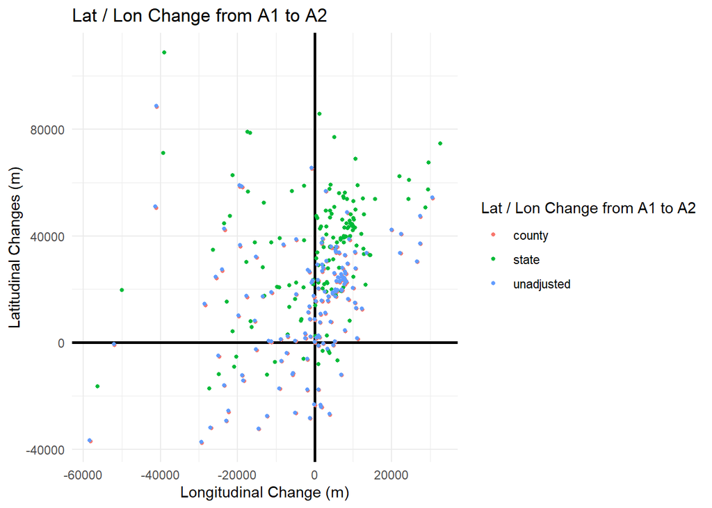

```r
plot_bias_adj <- function(atlas, X, Y, col, title, x.title, y.title) {
  ggplot(atlas, aes(x = !!sym(X), y = !!sym(Y), color = !!sym(col))) +
    geom_hline(yintercept = 0, color = "black", linewidth = 1) +
    geom_vline(xintercept = 0, color = "black", linewidth = 1) +
    geom_point(size = 1) + # Increase dot size
    labs(
      title = title,
      x = x.title,
      y = y.title,
      color = title
    ) +
    theme_minimal()
}


plot_bias_adj(atlas=bias.compare, X="lon.change", Y="lat.change",
           col="adjustment", title="Lat / Lon Change from A1 to A2",
           x.title="Longitudinal Change (m)", y.title="Latitudinal Changes (m)")
```

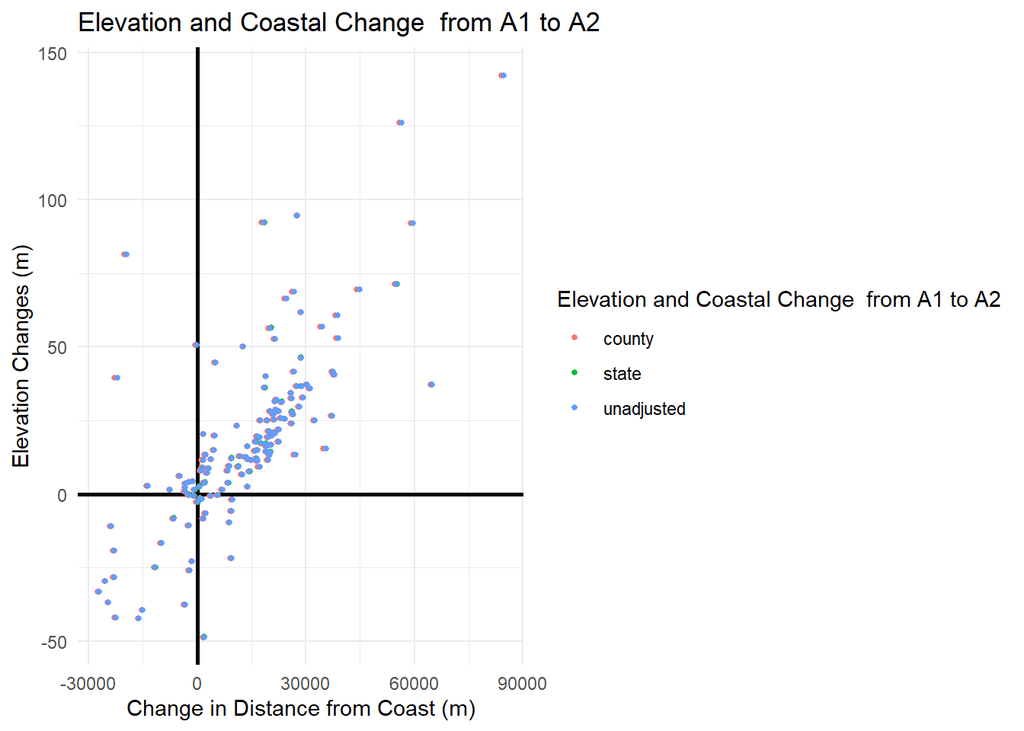

```r
plot_bias_adj(atlas=bias.compare, X="coast.change", Y="ele.change",
           col="adjustment", title="Elevation and Coastal Change  from A1 to A2",
           x.title="Change in Distance from Coast (m)", y.title="Elevation Changes (m)")
```

Bar chart of species bias adjustment, old adjustment, and no adjustment for each species. Use comparison=bias.compare to see statewide vs county vs unadjusted. Use comparison=bias.compare.county tp see just county vs unadjusted.

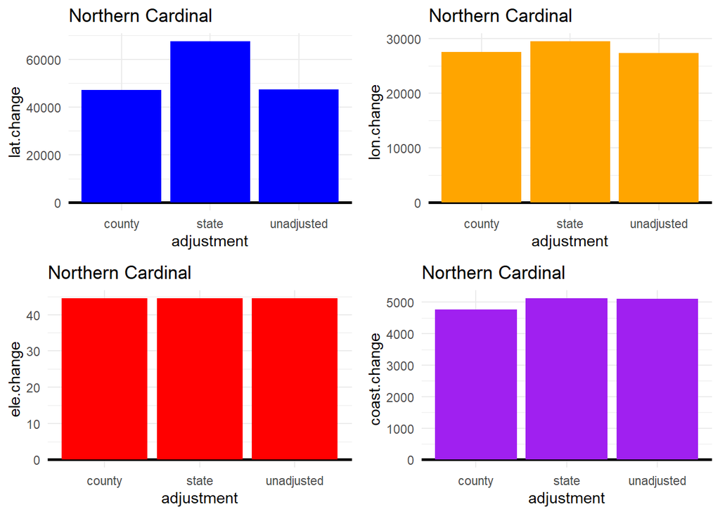

```r
species_bias_adj <- function(bird, comparison) {
  group <- comparison %>%
    filter(species == bird)
  lat.bar <- ggplot(data = group, aes(x = adjustment, y = lat.change)) +
    # geom_point(size = 1) +
    geom_hline(yintercept = 0, color = "black", linewidth = 1) +
    geom_bar(stat = "identity", fill = "blue") +
    labs(title = bird) +
    theme_minimal()
  lon.bar <- ggplot(data = group, aes(x = adjustment, y = lon.change)) +
    # geom_point(size = 1) +
    geom_hline(yintercept = 0, color = "black", linewidth = 1) +
    geom_bar(stat = "identity", fill = "orange") +
    labs(title = bird) +
    theme_minimal()
  ele.bar <- ggplot(data = group, aes(x = adjustment, y = ele.change)) +
    # geom_point(size = 1) +
    geom_hline(yintercept = 0, color = "black", linewidth = 1) +
    geom_bar(stat = "identity", fill = "red") +
    labs(title = bird) +
    theme_minimal()

  coast.bar <- ggplot(data = group, aes(x = adjustment, y = coast.change)) +
    # geom_point(size = 1) +
    geom_hline(yintercept = 0, color = "black", linewidth = 1) +
    geom_bar(stat = "identity", fill = "purple") +
    labs(title = bird) +
    theme_minimal()
  grid.arrange(lat.bar, lon.bar, ele.bar, coast.bar, ncol=2)
}
species_bias_adj("Northern Cardinal", bias.compare)
```

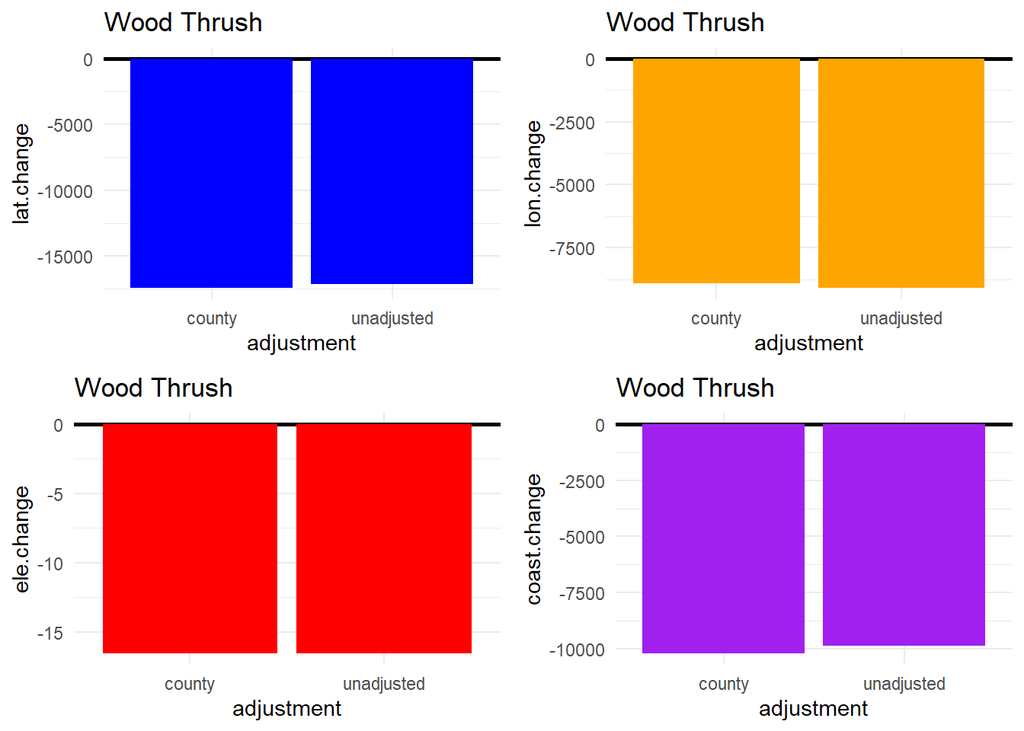

```r
# species_bias_adj("Tufted Titmouse")
species_bias_adj("Wood Thrush", bias.compare.county)
```

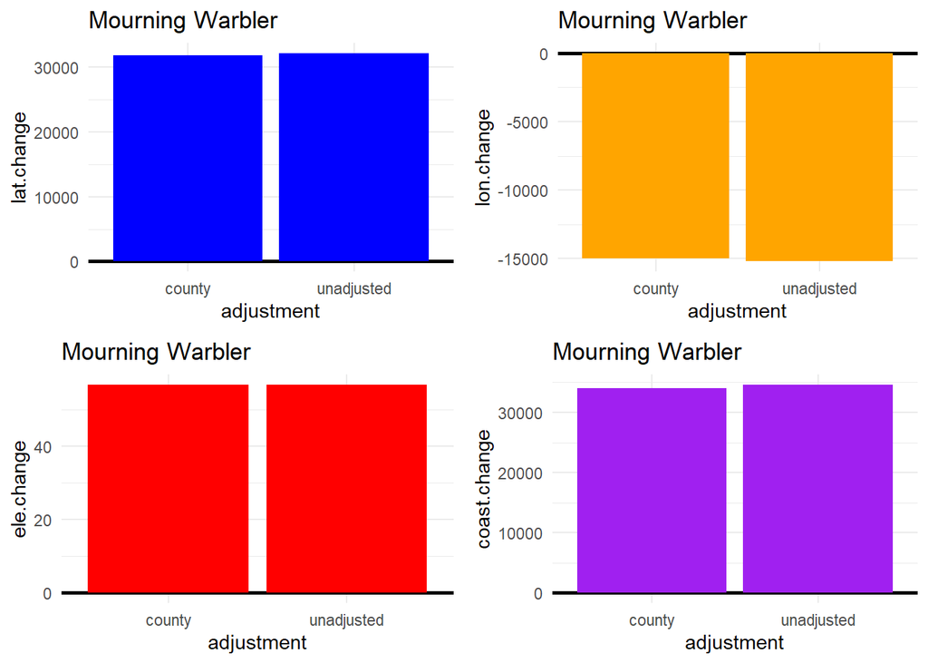

```r
species_bias_adj("Mourning Warbler", bias.compare.county)
```

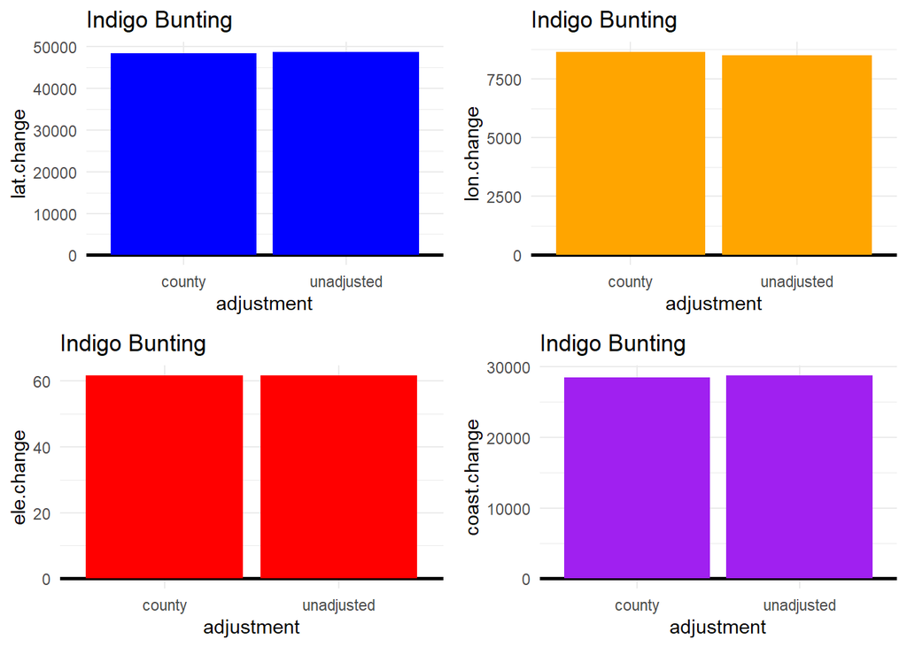

```r
species_bias_adj("Indigo Bunting", bias.compare.county)
```

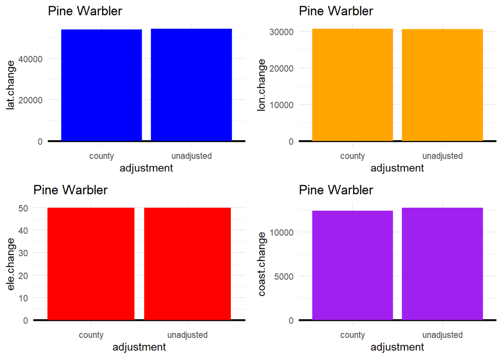

```r
species_bias_adj("Pine Warbler", bias.compare.county)
```

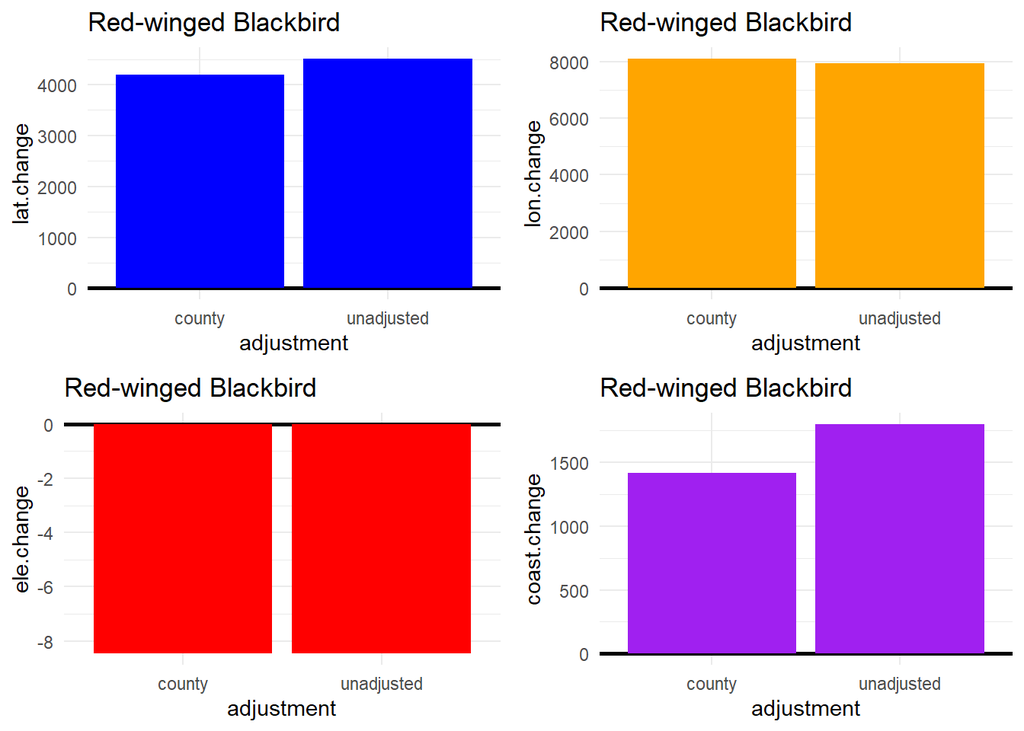

```r
species_bias_adj("Red-winged Blackbird", bias.compare.county)
```

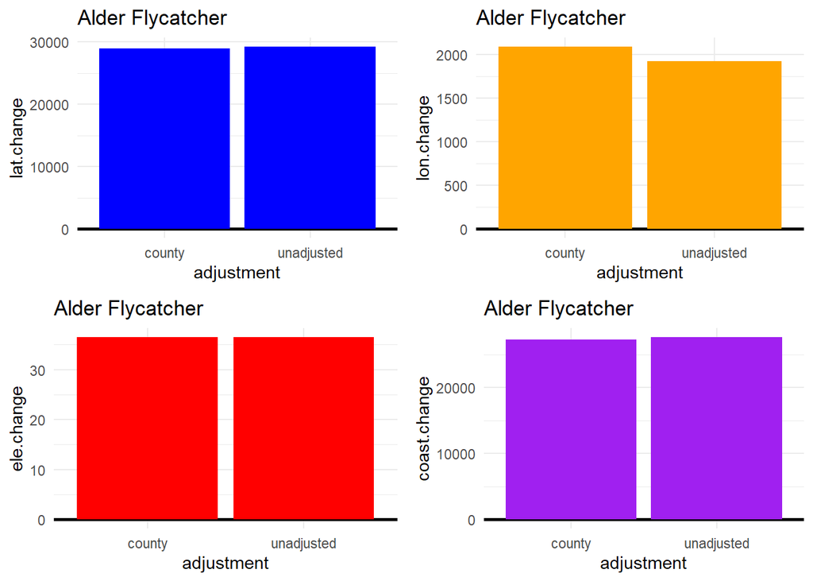

```r
species_bias_adj("Alder Flycatcher", bias.compare.county)
```

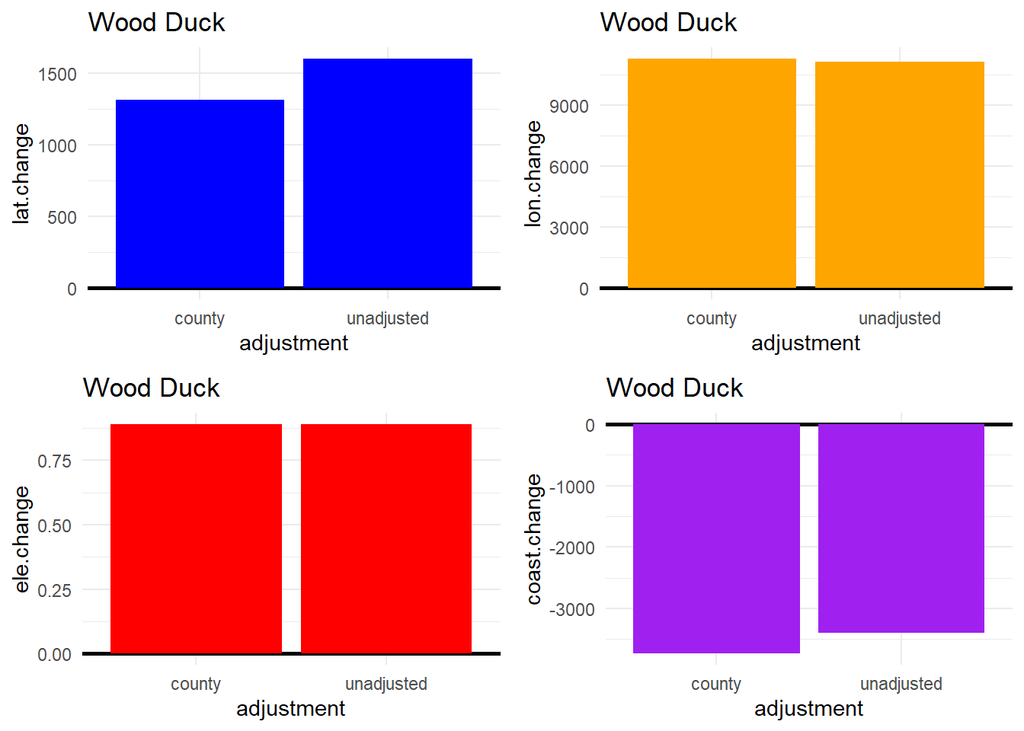

```r
species_bias_adj("Wood Duck", bias.compare.county)
```

Function: plot frequencies of changes in 4 variables

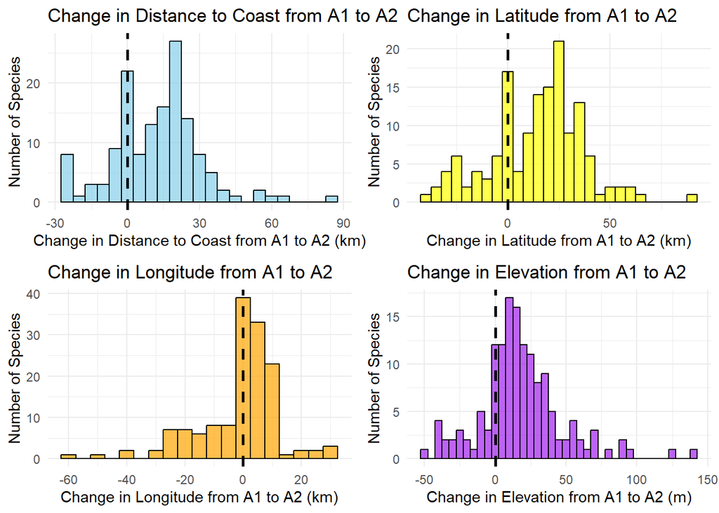

```r
histo <- function(col, hue, name, unit) {
  ggplot(freq.a2.km, aes(x = !!sym(col))) +
  geom_histogram(binwidth = 5, fill = hue, color = "black", alpha = 0.7) +
  geom_vline(xintercept=0, linetype="dashed",
              color = "black", linewidth=1) +
  labs(
    title = name,
    x = paste(name, unit),
    y = "Number of Species"
  ) +
  theme_minimal()
}


histo1 <- histo('coast.change', 'skyblue', "Change in Distance to Coast from A1 to A2", '(km)')
histo2 <- histo('lat.change', 'yellow', "Change in Latitude from A1 to A2", '(km)')
histo3 <- histo('lon.change', 'orange', "Change in Longitude from A1 to A2", '(km)')
histo4 <- histo('ele.change', 'purple', 'Change in Elevation from A1 to A2', '(m)')

grid.arrange(histo1, histo2, histo3, histo4, ncol = 2)
```

Plot boundaries for any species with 40 or more occurrences

```r
plot_boundaries <- function(bird) {
  # I use the unmodified (.u) version of the freq dfs so the boundary lines show
  # properly on a map
  boundary1 <- freq.a1 %>% filter(species == bird)
  boundary2 <- freq.a2 %>% filter(species == bird)
  # print(boundary1)
  # print(boundary2)
  maine_quads +
    geom_hline(data = boundary1, aes(yintercept = s.lat, color = "S Boundary A1"),
               show.legend = TRUE) +
    geom_hline(data = boundary1, aes(yintercept = n.lat, color = "N Boundary A1"),
               show.legend = TRUE) +
    geom_hline(data = boundary2, aes(yintercept = s.lat, color = "S Boundary A2"),
               show.legend = TRUE) +
    geom_hline(data = boundary2, aes(yintercept = n.lat, color = "N Boundary A2"),
               show.legend = TRUE) +
    scale_color_manual(
      name = "Boundary Lines",
      values = c(
        "S Boundary A1" = "red",
        "N Boundary A1" = "red",
        "S Boundary A2" = "blue",
        "N Boundary A2" = "blue"
      )
    ) +
    labs(
      title = paste0(bird, " Latitudinal Boundaries"),
      # title = paste0(bird, " Latitudinal Boundaries"),
      x = "Longitude",
      y = "Latitude"
    ) +
    theme_minimal()
}

if (generate.maps) {
  for (i in freq.a1$species) {
    map <- plot_boundaries(i)
    # p.shift <- paste0("Distribution Center Shift for ", i)
    file.shift <- paste0(i, '.jpg')
    ggsave(filename = file.shift, path = '..\\boundary_shift_plots', plot = map,
           dpi = 1200)

  }
}
# map <- plot_boundaries(freq.a1$species[1])
# map
# lapply(freq.a1$species, plot_boundaries)
```

Plot Elevation by bird group in atlas 2 to see relation between mean and average Data in centimeters according to: https://www.epa.gov/hydrowq/metadata-national-elevation-dataset-ned#Identification_Information

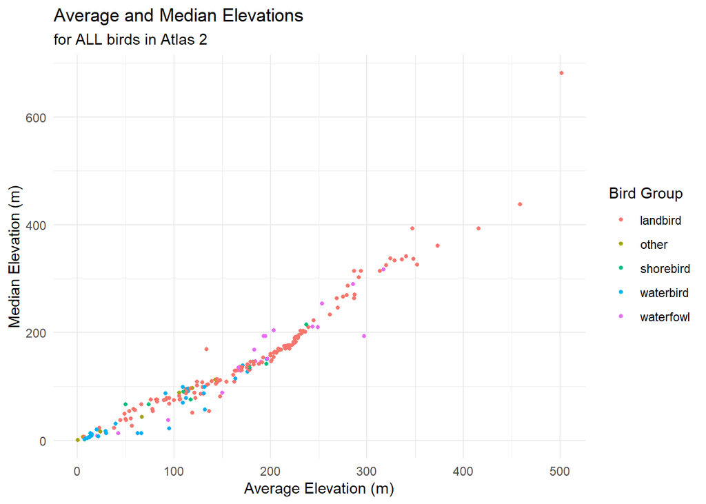

```r
ggplot(bba2m.dist, aes(x = avg.ele, y = med.ele, color = bird.group)) +
  geom_point(size = 1) + # Increase dot size
  labs(
    title = "Average and Median Elevations",
    subtitle = "for ALL birds in Atlas 2",
    x = "Average Elevation (m)",
    y = "Median Elevation (m)",
    color = "Bird Group"
  ) +
  theme_minimal()
```

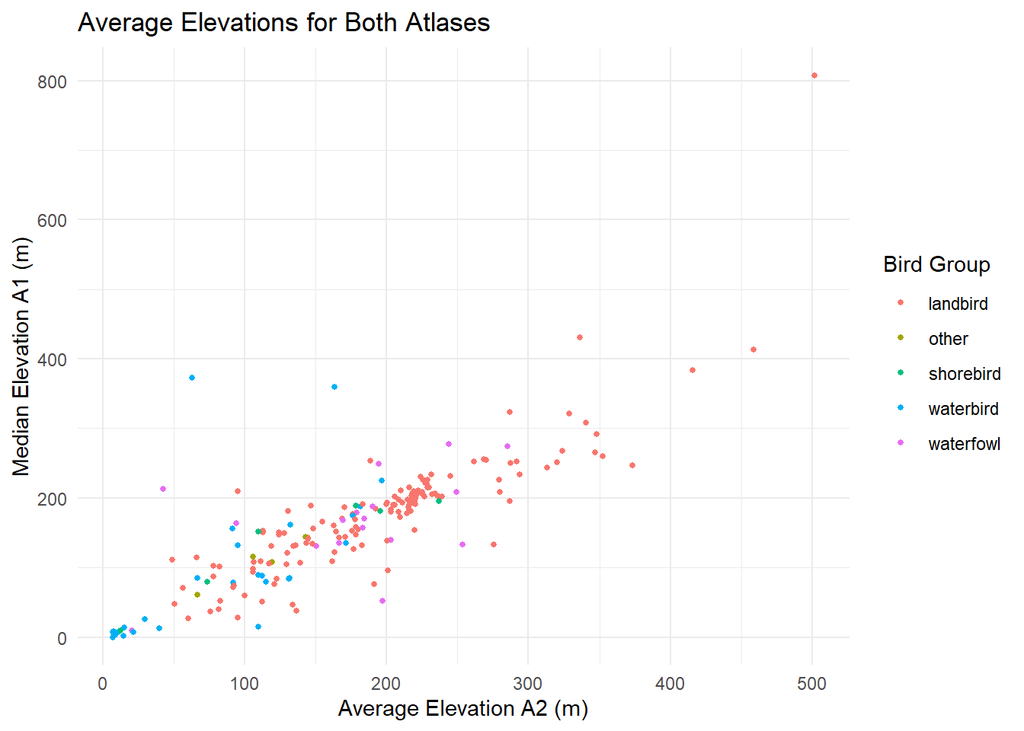

```r
common.a2$avg.ele.a1 <- common.a1$avg.ele
ggplot(common.a2, aes(x = avg.ele, y = avg.ele.a1, color = bird.group)) +
  geom_point(size = 1) + # Increase dot size
  labs(
    title = "Average Elevations for Both Atlases",
    x = "Average Elevation A2 (m)",
    y = "Median Elevation A1 (m)",
    color = "Bird Group"
  ) +
  theme_minimal()
```

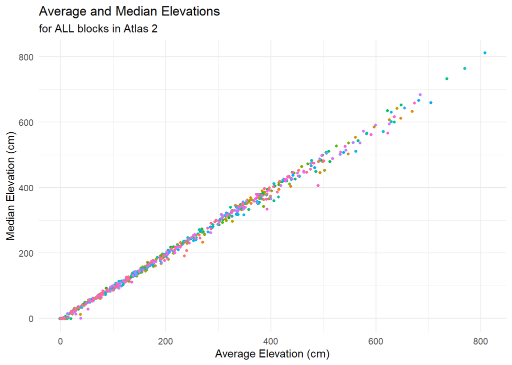

```r
ggplot(bba2m, aes(x = avg.ele, y = med.ele, color = QuadNameCo)) +
  geom_point(size = 1) + # Increase dot size
  labs(
    title = "Average and Median Elevations",
    subtitle = "for ALL blocks in Atlas 2",
    x = "Average Elevation (cm)",
    y = "Median Elevation (cm)",
    color = "Bird Group"
  ) +
  theme_minimal() +
  guides(color = FALSE)
```

Intialize center_limit function

```r
center_limit <- function(one_bird, bird, min, max, mid, plot_name, y_axis, da)
{

  common_columns <- intersect(names(freq.a1.km), names(freq.a2))

  sym.mid <- ensym(mid)
  sym.min <- ensym(min)
  sym.max <- ensym(max)

  one.bird.a2 <- freq.a2.km[, common_columns]

  one.bird.a1 <- freq.a1.km[, common_columns]
  if (one_bird){
    one.bird.a2 <- one.bird.a2 %>%
      filter(species == bird)
    one.bird.a1 <- one.bird.a1 %>%
      filter(species == bird)
  }

  one.bird.a1$atlas <- "A1"
  one.bird.a1
  one.bird.a2$atlas <- "A2"
  one.bird.a2
  one.bird <- rbind(one.bird.a1, one.bird.a2)

  p <- ggplot(one.bird, aes(x = atlas, y = !!sym(mid), color = bird.group)) +
      geom_point(position = position_dodge(width = 0.5)) +
      labs(x = "Atlas", y = y_axis, title = plot_name) +
      theme_minimal()


  if (one_bird) {
    p <- p + geom_errorbar(aes(ymin = !!sym(min), ymax = !!sym(max)), width = 0.2,
                           position = position_dodge(width = 0.2)) +
      theme(legend.position = "none")
  }

  return(p)
  print("complete H")
}

# center_limit(TRUE, "Northern Cardinal", 's.lat', 'n.lat', 'lat', "Center & Limit of Latitude for Northern Cardinal NO BIAS ADJUSTMENT", 'Latitude (m)', da.lat)
```

Create a center and limit plot for each species

```r
if (generate.maps) {
  for (i in 1:nrow(freq.a1.km)) {
    row1 <- freq.a1.km[i, ]
    row2 <- freq.a2.km[i, ]
    b <- unlist(row1$species)

    t.lat <- paste0("Center & Limit of Latitude for ", b)
    t.lon <- paste0("Center & Limit of Longitude for ", b)
    t.ele <- paste0("Center & Limit of Elevation for ", b)
    t.c <- paste0("Center & Limit of Distance to Coast for ", b)

    p.lat <- center_limit(TRUE, b, 's.lat', 'n.lat', 'lat', t.lat, 'Latitude (km)',
                          da = da.lat)
    p.lon <- center_limit(TRUE, b, 'w.lon', 'e.lon', 'lon', t.lon, 'Longitude (km)',
                          da.lat)
    p.ele <- center_limit(TRUE, b, 'min.ele', 'max.ele', 'avg.ele', t.ele,
                          'Elevation (m)', da.ele)
    p.c <- center_limit(TRUE, b, 'min.coast', 'max.coast', 'd.to.coast', t.c,
                 'Distance to Coast (km)', da.coast)

    file.lat <- paste0(t.lat, '.jpg')
    file.lon <- paste0(t.lon, '.jpg')
    file.ele <- paste0(t.ele, '.jpg')
    file.c <- paste0(t.c, '.jpg')

    ggsave(filename = file.lat, path = '..\\center_lim_plots', plot = p.lat,
           dpi = 1200)
    ggsave(filename = file.lon, path = '..\\center_lim_plots', plot = p.lon,
           dpi = 1200)
    ggsave(filename = file.ele, path = '..\\center_lim_plots', plot = p.ele,
           dpi = 1200)
    ggsave(filename = file.c, path = '..\\center_lim_plots', plot = p.c,
           dpi = 1200)

  }
}
```

Plot centers for each of the 4 variables

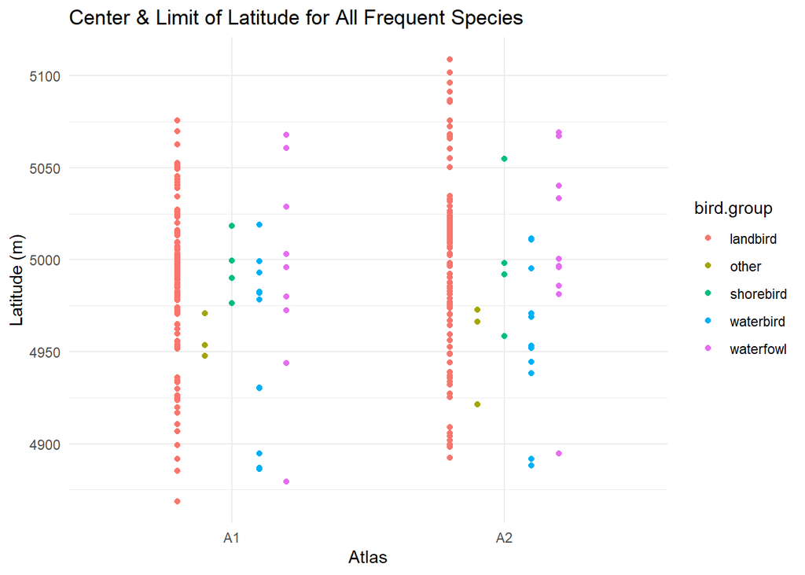

```r
# center_limit(TRUE, "Alder Flycatcher", 's.lat', 'n.lat', 'lat', "Center & Limit of Latitude for Alder Flycatcher", 'Latitude (m)', da.lat)
center_limit(FALSE, "Alder Flycatcher", 's.lat', 'n.lat', 'lat', "Center & Limit of Latitude for All Frequent Species", 'Latitude (m)', da.lat)
```

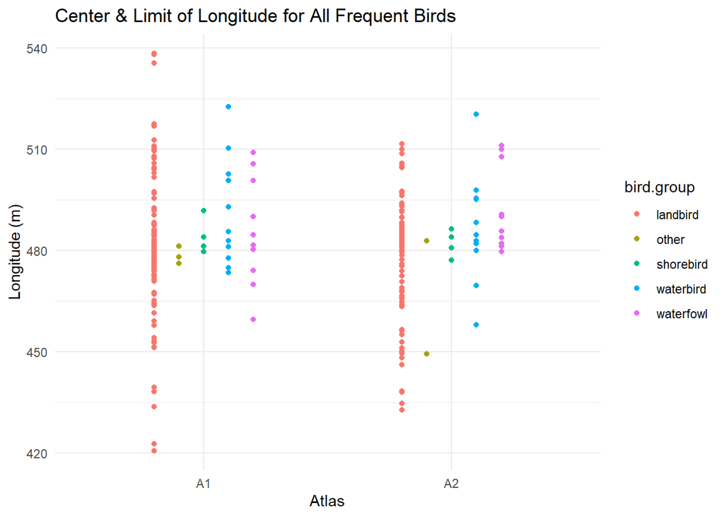

```r
# center_limit(TRUE, "Alder Flycatcher", 'w.lon', 'e.lon', 'lon', "Center & Limit of Longitude for Alder Flycatcher", 'Longitude (m)', da.lon)
center_limit(FALSE, "Alder Flycatcher", 'w.lon', 'e.lon', 'lon', "Center & Limit of Longitude for All Frequent Birds", 'Longitude (m)', da.lon)
```

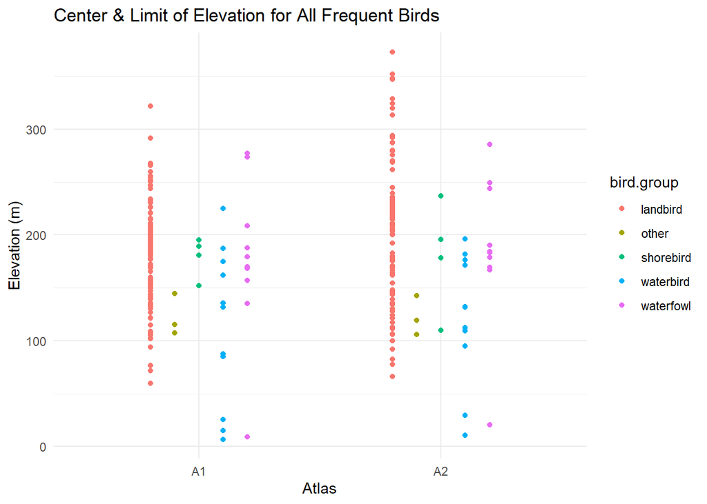

```r
# center_limit(TRUE, "Alder Flycatcher", 'min.ele', 'max.ele', 'avg.ele', "Center & Limit of Elevation for Alder Flycatcher", 'Elevation (m)', da.ele)
center_limit(FALSE, "Alder Flycatcher", 'min.ele', 'max.ele', 'avg.ele', "Center & Limit of Elevation for All Frequent Birds", 'Elevation (m)', da.ele)
```

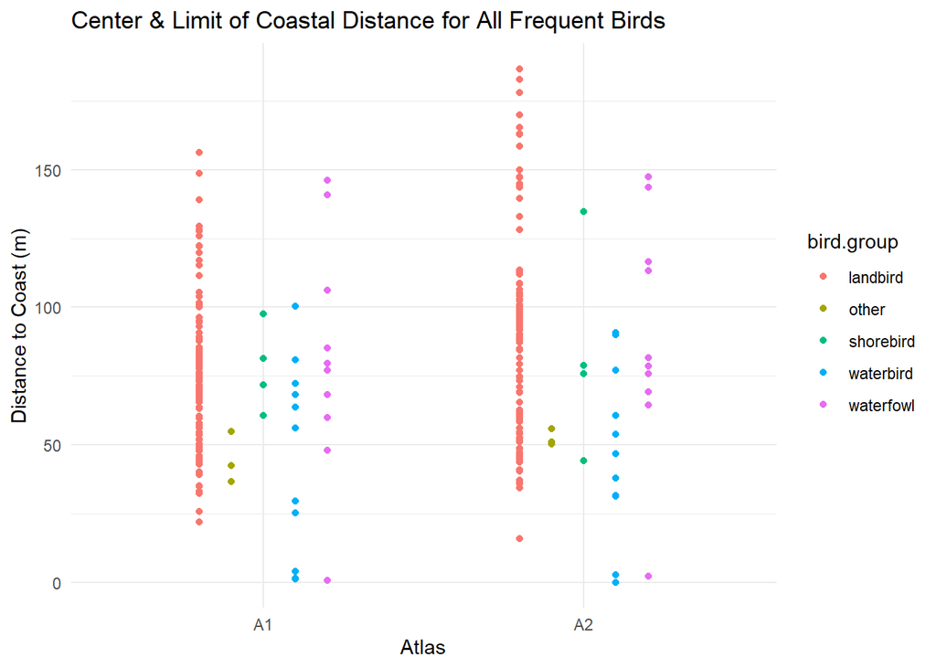

```r
# center_limit(TRUE, "Alder Flycatcher", 'min.coast', 'max.coast', 'd.to.coast', "Center & Limit of Coastal Distance for Alder Flycatcher", 'Distance to Coast (m)', da.coast)

center_limit(FALSE, "Alder Flycatcher", 'min.coast', 'max.coast', 'd.to.coast', "Center & Limit of Coastal Distance for All Frequent Birds", 'Distance to Coast (m)', da.coast)
```

```r
parulidae_indices <- which(freq.a2$Family == "Parulidae")

# Define the split points
n <- length(parulidae_indices)
n
```

```
## [1] 23
```

```r
split_points <- c(8, 16)

freq.a1$Family[parulidae_indices[1:split_points[1]]] <- "Parulidae 1/3"
freq.a1$Family[parulidae_indices[(split_points[1] + 1):split_points[2]]] <- "Parulidae 2/3"
freq.a1$Family[parulidae_indices[(split_points[2] + 1):n]] <- "Parulidae 3/3"

freq.a2$Family[parulidae_indices[1:split_points[1]]] <- "Parulidae 1/3"
freq.a2$Family[parulidae_indices[(split_points[1] + 1):split_points[2]]] <- "Parulidae 2/3"
freq.a2$Family[parulidae_indices[(split_points[2] + 1):n]] <- "Parulidae 3/3"
```

Initialize shift.sf data.frame to plot shift arrows on a map

```r
# A1 has no bias factor to account for
start_coords <- st_coordinates(freq.a1$geometry)
end_coords <- st_coordinates(freq.a2$geometry)

# initialize linestrings
shift_lines <- lapply(1:nrow(start_coords), function(i) {
  st_linestring(matrix(c(start_coords[i, ], end_coords[i, ]), ncol = 2, byrow = TRUE))
})
# convert linestrings to sf
shift.sf <- st_sf(geometry = st_sfc(shift_lines), crs = st_crs(freq.a1))
shift.sf <- st_sf(species = freq.a1$species, family = freq.a1$Family,
                  bird.group = freq.a1$bird.group,
                  geometry = st_sfc(shift_lines), crs = st_crs(freq.a1))


coords <- lapply(shift.sf$geometry, function(x) st_coordinates(x))


lat.diff <- sapply(coords, function(coord) coord[2, 2] - coord[1, 2])

shift.sf$lat.shift <- lat.diff > 0
shift.sf <- shift.sf %>%
  mutate(lat.shift = ifelse(lat.shift, "North", "South"))
shift.sf
```

```
## Simple feature collection with 145 features and 4 fields
## Geometry type: LINESTRING
## Dimension:     XY
## Bounding box:  xmin: 420944.5 ymin: 4868518 xmax: 538699.4 ymax: 5108979
## Projected CRS: WGS 84 / UTM zone 19N
## First 10 features:
##                species        family bird.group                       geometry
## 1     Alder Flycatcher    Tyrannidae   landbird LINESTRING (483106.8 498937...
## 2     American Bittern      Ardeidae  waterbird LINESTRING (483020.4 499882...
## 3  American Black Duck      Anatidae  waterfowl LINESTRING (484862.3 499549...
## 4        American Crow      Corvidae   landbird LINESTRING (478510.4 498669...
## 5   American Goldfinch  Fringillidae   landbird LINESTRING (479026.5 497855...
## 6     American Kestrel    Falconidae   landbird LINESTRING (481199.7 497371...
## 7    American Redstart Parulidae 1/3   landbird LINESTRING (475680.6 499273...
## 8       American Robin      Turdidae   landbird LINESTRING (477578.6 499806...
## 9    American Woodcock  Scolopacidae  shorebird LINESTRING (484191.1 498957...
## 10          Bald Eagle  Accipitridae   landbird LINESTRING (538699.4 499693...
##    lat.shift
## 1      North
## 2      North
## 3      North
## 4      North
## 5      North
## 6      North
## 7      North
## 8      North
## 9      North
## 10     South
```

Map center of distribution changes with arrows

```r
# to change it back to original plots, set color to lat.shift, filter by group,
# and change legend title

families <- unique(freq.a2$Family)

# define function for creating arrow maps
arrow_map <- function(fam) {
  shift.group <- shift.sf %>%
    filter(family == fam)

  arrows <- maine_quads +
    geom_sf(data = shift.group, aes(geometry = geometry, color = species), arrow =
            arrow(length = unit(0.2, "cm"))) +
    # scale_color_manual(name = "Latitudinal Direction of Shift") +
    theme_minimal() +
    labs(title = paste0("Center of Distribution Shift from A1 to A2 for ", fam),
         color = "Species")
  return(arrows)
}


# apply to each family of bird species and save as a jpeg
if (generate.maps) {
  for (i in families) {
    map <- arrow_map(i)
    # p.shift <- paste0("Distribution Center Shift for ", i)
    file.shift <- paste0(i, '.jpg')
    ggsave(filename = file.shift, path = '..\\center_shift_plots', plot = map,
           dpi = 1200)

  }
}
# shift.maps <- lapply(families, arrow_map)
# shift.maps
```

Map center of distribution changes with arrows

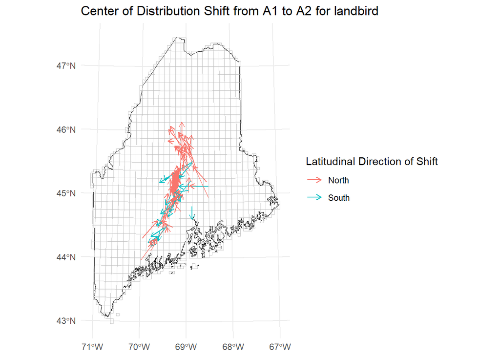

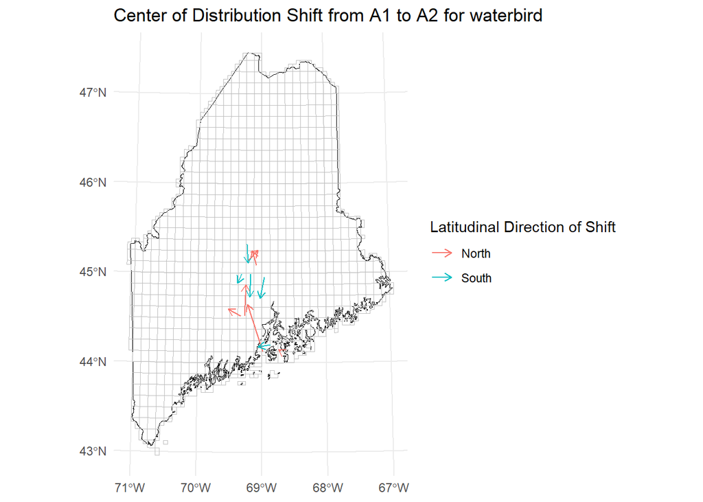

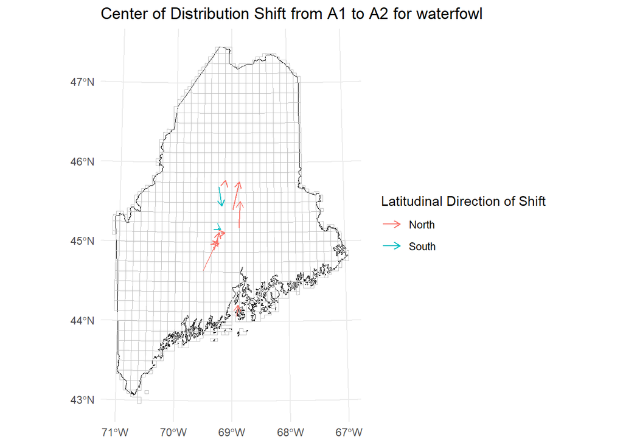

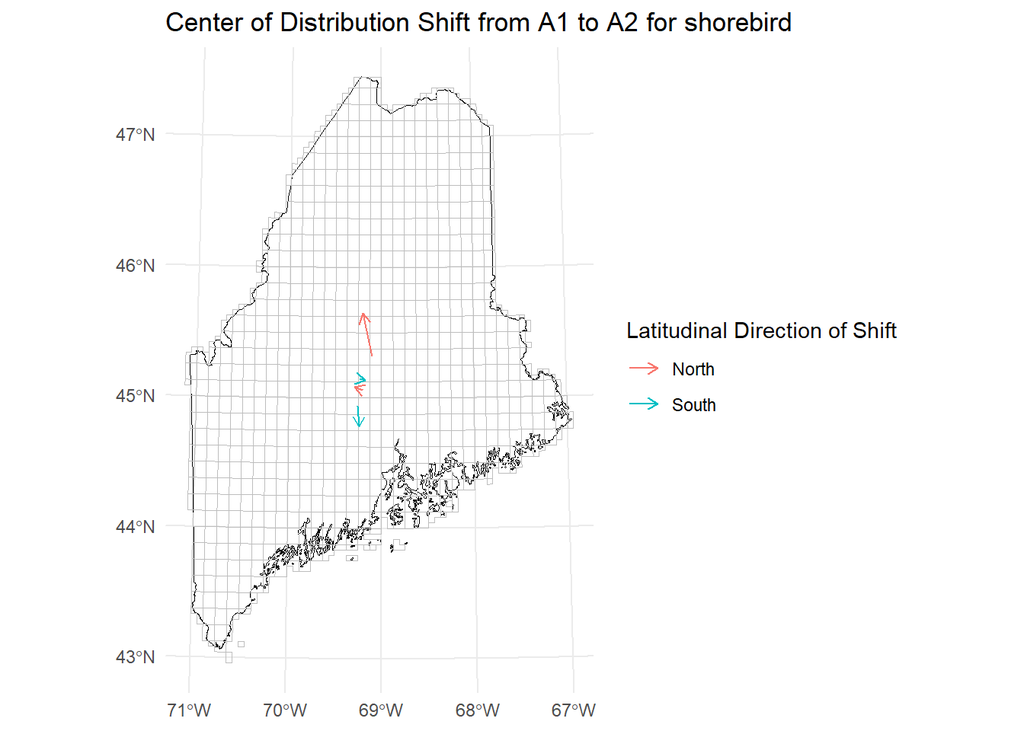

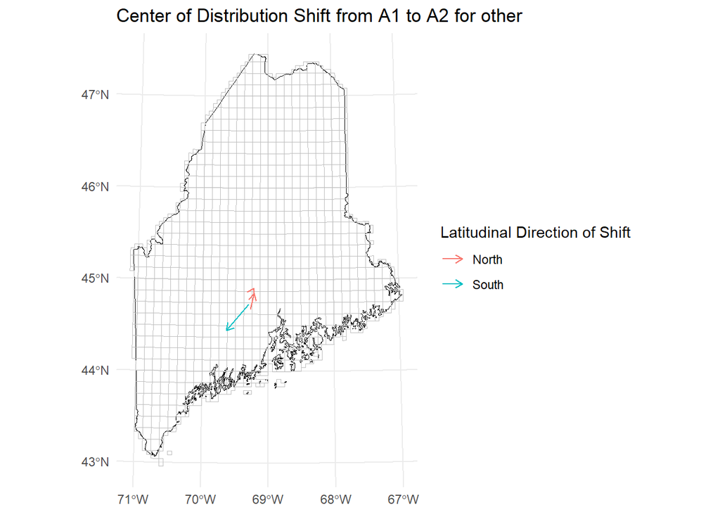

```r
# to change it back to original plots, set color to lat.shift, filter by group,
# and change legend title

groups <- unique(freq.a2$bird.group)


arrow_map_group <- function(g) {
  shift.group <- shift.sf %>%
    filter(bird.group == g)

  arrows <- maine_quads +
    geom_sf(data = shift.group, aes(geometry = geometry, color = lat.shift), arrow =
            arrow(length = unit(0.2, "cm"))) +
    # scale_color_manual(name = "Latitudinal Direction of Shift") +
    theme_minimal() +
    labs(title = paste0("Center of Distribution Shift from A1 to A2 for ", g),
         color = "Latitudinal Direction of Shift")
  return(arrows)
}

shift.maps <- lapply(groups, arrow_map_group)
shift.maps
```

Create Color Scale Map for Elevation and Coastal Change

```
## [1] "coast.change"
```

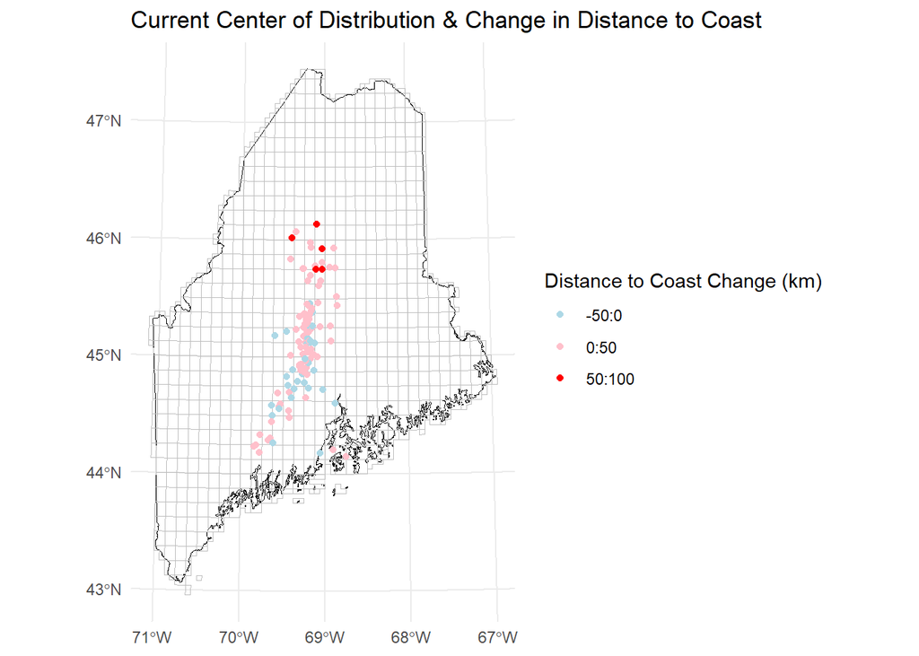

```r
c_scale_categories <- function(var, key, title) {
  var_sym <- ensym(var)  # Convert the input to a symbol
  print(var)
  # Create a new categorical variable based on the specified ranges
  freq.a2.km <- freq.a2.km %>%
    mutate(value_category = case_when(
      !!var_sym >= -200 & !!var_sym < -100 ~ "-200:-100",
      !!var_sym >= -100 & !!var_sym < -50 ~ "-100:-50",
      !!var_sym >= -50 & !!var_sym < 0 ~ "-50:0",
      !!var_sym >= 0 & !!var_sym < 50 ~ "0:50",
      !!var_sym >= 50 & !!var_sym < 100 ~ "50:100",
      !!var_sym  >= 100 & !!var_sym < 200 ~ "100:200"
    ))

  # freq.a2.km <- freq.a2.km %>%
  #    mutate(value_category = ifelse(var >= -200 & var < -100, "-200:-100",
  #                                   "out of range"))
  # freq.a2.km <- freq.a2.km %>%
  #   mutate(value_category = ifelse(var >= -100 & var < 0, "-100:0",
  #                                   value_category))
  # freq.a2.km <- freq.a2.km %>%
  #   mutate(value_category = ifelse(var >= 0 & var < 100, "0:100",
  #                                   value_category))
  # freq.a2.km <- freq.a2.km %>%
  #   mutate(value_category = ifelse(var >= 100 & var < 200, "100:200",
  #                                   value_category))

  maine_quads +
    geom_sf(data = freq.a2.km,
            aes(geometry = geometry, color = value_category)) +
    scale_color_manual(name = key,
                       values = c(
                         "-200:-100" = "darkblue",
                         "-100:-50" = "blue",
                         "-50:0" = "lightblue",
                         "0:50" = "pink",
                         "50:100" = "red",
                         "100:200" = "darkred"
                       )) +
    theme_minimal() +
    labs(title = title)
}

c_scale_categories("coast.change", "Distance to Coast Change (km)",
                   "Current Center of Distribution & Change in Distance to Coast")
```

```r
c_scale_categories("ele.change", "Elevation Change (m)",
                   "Current Center of Distribution & Change in Elevation")
```

[output not shown]

[figure not shown]

Create a species count for each block

```r
# create atlas 1 species list to iterate through
start_col <- which(names(bba1m) == "American Black Duck")
end_col <- which(names(bba1m) == "Yellow-throated Vireo")
species.a1 <- colnames(bba1m)[start_col:end_col]
# create atlas 1 species list to iterate through
start_col <- which(names(bba2m) == "Acadian Flycatcher")
end_col <- which(names(bba2m) == "Yellow Warbler")
species.a2 <- colnames(bba2m)[start_col:end_col]

bba1m.species <- subset(bba1m, select = species.a1)
bba2m.species <- subset(bba2m, select = species.a2)


# this function returns the count of non NA values in a row
sum_binary <-  function(row) {
  row <- as.list(row)

  # Remove the last element (which is the sf_point)
  row <- row[-length(row)]
  new_row <- sapply(row, function(x) ifelse(is.na(x) | x == 0, 0, 1))
  # this statement had to be separate in order to ensure all values were numeric
  # new_row <- sapply(row, function(x) ifelse(x == 2 | x == 0, 0, 1))
  # print(new_row)
  row_count <- sum(new_row)
  return(row_count)
}
count.a1 <- vector()
count.a2 <- vector()
for (i in 1:nrow(bba1m.species)) {
  # atlas 1
  current_row.a1 <- bba1m.species[i, ]
  count.a1 <- c(count.a1, sum_binary(current_row.a1))
  # atlas 2
  current_row.a2 <- bba2m.species[i, ]
  count.a2 <- c(count.a2, sum_binary(current_row.a2))
}

bba1m.species <- bba1m.species %>%
  mutate(species_count = count.a1)
bba2m.species <- bba2m.species %>%
  mutate(species_count = count.a2)

# A1 is subtracted from A2 to show an increase overtime as positive
bba2m.species <- bba2m.species %>%
  mutate(count_diff = species_count - bba1m.species$species_count)

bba2m.species <- bba2m.species %>%
  mutate(diff_rank = ifelse(count_diff > 0, 'increase', 'same'))

bba2m.species <- bba2m.species %>%
  mutate(diff_rank = ifelse(count_diff < 0, 'decrease', diff_rank))
max(bba2m.species$species_count)
```

```
## [1] 175
```

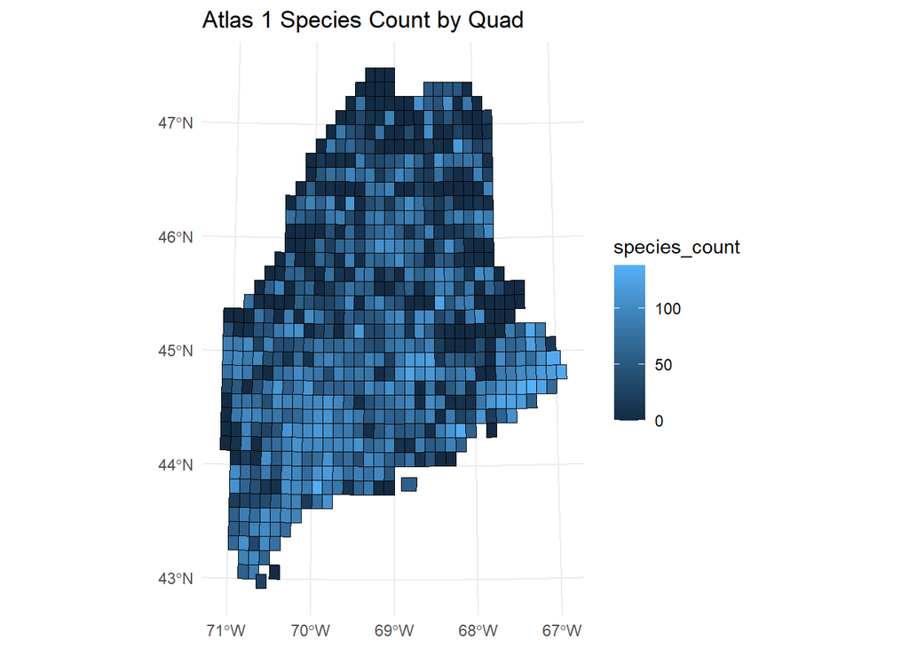

```r
ggplot() +
  geom_sf(data = bba1m.species, aes(geometry = geometry, fill = species_count),
          color = "black") +
  labs(title = "Atlas 1 Species Count by Quad") +
  theme_minimal()
```